# Nevada Housing Project

## Introduction

I got this dataset from a Data Analyst, Jose Portila. I watched his tutorials for data analysis online, and really like the dataset he used. I downloaded the dataset and added few columns from Kaggle. The dataset would have 7 variables and collected by Zillow in 2016. I will extend the analysis and combine data science model to estimate of what the house would sell for.

Since the Housing dataset is continuious, so I chose Linear Regression model for this project.

## Import Libraries and Packages

```python
# import data analysis libraries
import pandas as pd
import numpy as np
```

```python
# import data visualization libraries
import matplotlib.pyplot as plt
import seaborn as sns
%matplotlib inline
```

## Dataset Checkout

```python
housing = pd.read_csv('Nevada_Housing.csv')
```

```python
housing.info()     # info() command can tell you the structure of the dataset
```

```
<class 'pandas.core.frame.DataFrame'>
RangeIndex: 5000 entries, 0 to 4999
Data columns (total 7 columns):
Avg. Area Income                5000 non-null float64
Avg. Area House Age             5000 non-null float64
Avg. Area Number of Rooms       5000 non-null float64
Avg. Area Number of Bedrooms    5000 non-null float64
Area Population                 5000 non-null float64
Price                           5000 non-null float64
Address                         5000 non-null object
dtypes: float64(6), object(1)
memory usage: 273.6+ KB
```

```python
housing.describe()     # we can see some statistical values for the dataset
```

|  | Avg. Area Income | Avg. Area House Age | Avg. Area Number of Rooms | Avg. Area Number of Bedrooms | Area Population | Price |
| --- | --- | --- | --- | --- | --- | --- |
| count | 5000.000000 | 5000.000000 | 5000.000000 | 5000.000000 | 5000.000000 | 5.000000e+03 |
| mean | 68583.108984 | 5.977222 | 6.987792 | 3.981330 | 36163.516039 | 1.232073e+06 |
| std | 10657.991214 | 0.991456 | 1.005833 | 1.234137 | 9925.650114 | 3.531176e+05 |
| min | 17796.631190 | 2.644304 | 3.236194 | 2.000000 | 172.610686 | 1.593866e+04 |
| 25% | 61480.562388 | 5.322283 | 6.299250 | 3.140000 | 29403.928702 | 9.975771e+05 |
| 50% | 68804.286404 | 5.970429 | 7.002902 | 4.050000 | 36199.406689 | 1.232669e+06 |
| 75% | 75783.338666 | 6.650808 | 7.665871 | 4.490000 | 42861.290769 | 1.471210e+06 |
| max | 107701.748378 | 9.519088 | 10.759588 | 6.500000 | 69621.713378 | 2.469066e+06 |

```python
housing.columns     # we can see there are 7 columns (variables) in total
```

```
Index(['Avg. Area Income', 'Avg. Area House Age', 'Avg. Area Number of Rooms',
       'Avg. Area Number of Bedrooms', 'Area Population', 'Price', 'Address'],
      dtype='object')
```

The following list is the description of each variable:

- Avg. Area Income: average income of residents of the city house is located in
- Avg. Area House Age: average age of houses in same city
- Avg. Area Number of Rooms: average number of rooms for houses in same city
- Avg. Area Number of Bedrooms: average number of bedrooms for houses in same city
- Area Population: population of city house is located in
- Price: price that the house sold at
- Address: address for the house

## Exploratory Data Analysis

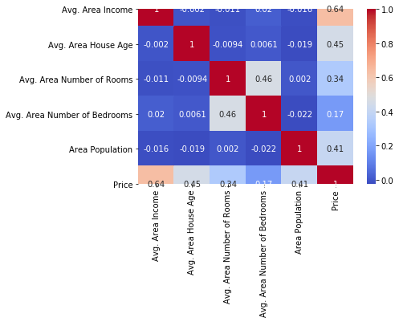

```python
sns.heatmap(housing.corr(), annot = True, cmap='coolwarm')     # we can see the correlation between all variables
```

As the plot shown above, the correlation value larger, two variables have higher relevance.

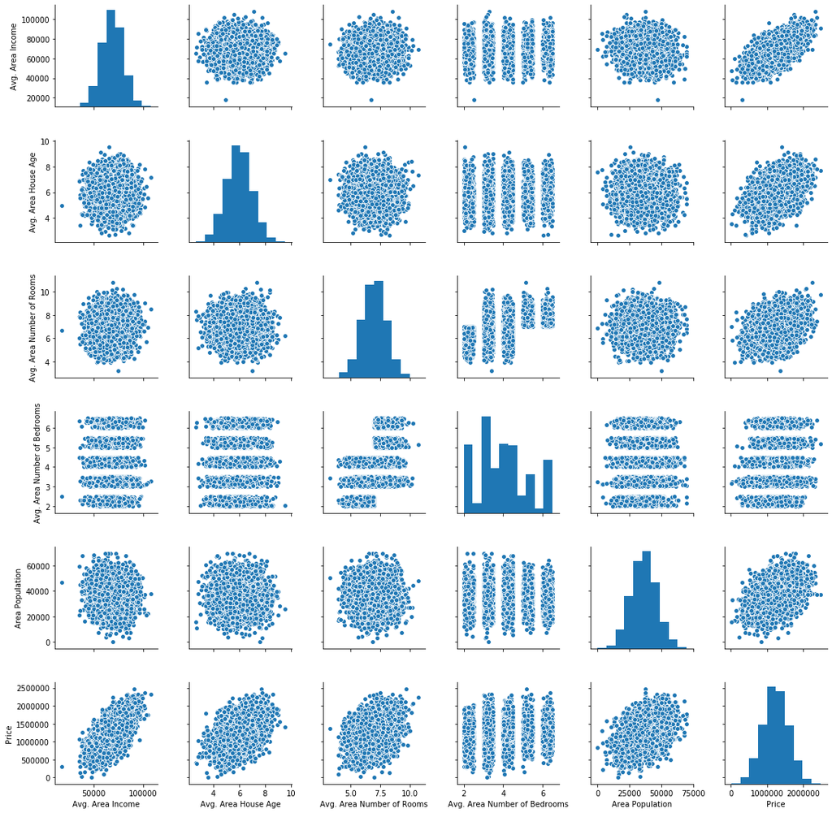

```python
sns.pairplot(housing)     # pairplot shows histograms and scatter plots
```

As the plot shown above, the histogram on the diagonal allows us to see the distribution of a single variable while the scatter plots on the upper and lower triangles show the relationship between two variables.

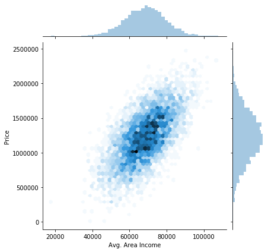

```python
# jointplot can compare single variable and the relationship between two variables at the same time
sns.jointplot(x = 'Avg. Area Income', y = 'Price', kind = 'hex', data = housing)
```

Due to the pairplot, I assume Avg. Area Income and Price have stronger relatioship than other variables, so I just check these two variables specifically.

## Training a Linear Regression Model

We need to split the dataset into an X array that contains the features to train onm and a y array with the target variable, in this case the Price column. We will remove the Address column to make the data easier to train.

```python
# we will show what are X and y arrays
X = housing[['Avg. Area Income', 'Avg. Area House Age', 'Avg. Area Number of Rooms',
       'Avg. Area Number of Bedrooms', 'Area Population']]
y = housing['Price']
```

```python
# now let's split the data into a training set and testing set. We will use scikit-learn package for the model
from sklearn.model_selection import train_test_split
```

```python
# we split into 70% training set and 30% testing set
X_train, X_test, y_train, y_test = train_test_split(X, y, test_size=0.3, random_state=101)
```

## Creating the Model

```python
# we need to import linear regression package in scikit-learn library
from sklearn.linear_model import LinearRegression
```

```python
lm = LinearRegression()
```

```python
lm.fit(X_train, y_train)     # we are fitting the model on the training set
```

```
LinearRegression(copy_X=True, fit_intercept=True, n_jobs=None, normalize=False)
```

## Predictions from our Model

Now that we have fit our model, let's evaluate its performance by predicting off the testing set.

```python
predictions = lm.predict(X_test)
```

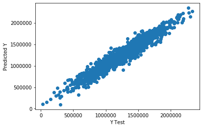

```python
plt.scatter(y_test, predictions)
plt.xlabel('Y Test')
plt.ylabel('Predicted Y')
```

We can see from the plot above, predicted values and testing values are highly correlated, it means our model works well.

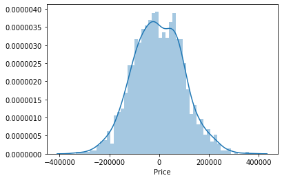

```python
# residual histogram (actual value - expected)
sns.distplot((y_test - predictions), bins = 50)
```

The residual histogram seems to have a normal distribution, it means we have a good model with a good fit.

## Conclusion

We will still want to figure out the original question we made in the introduction, what the house would sell for? Let's see if we can interpret the coefficients at all to get an idea.

```python
coef_housing = pd.DataFrame(lm.coef_, X.columns, columns = ['Coefficient'])
coef_housing
```

|  | Coefficient |
| --- | --- |
| Avg. Area Income | 21.617635 |
| Avg. Area House Age | 165221.119872 |
| Avg. Area Number of Rooms | 121405.376596 |
| Avg. Area Number of Bedrooms | 1318.718783 |
| Area Population | 15.225196 |

Interpreting the coefficients:

- Holding all other features fixed, a 1 unit increase in **Avg. Area Income** is associated with an **increase of \$21.62 in Price**.
- Holding all other features fixed, a 1 unit increase in **Avg. Area House Age** is associated with an **increase of \$165221.12 in Price**.
- Holding all other features fixed, a 1 unit increase in **Avg. Area Number of Rooms** is associated with an **increase of \$121405.38 in Price**.
- Holding all other features fixed, a 1 unit increase in **Avg. Area Number of Bedrooms** is associated with an **increase of \$1318.72 in Price**.
- Holding all other features fixed, a 1 unit increase in **Area Population** is associated with an **increase of \$15.23 in Price**.